# h-2.2

## Load Data

Copy/paste the following code block to your live Notebook and make sure it runs without error:

```
import pandas as pd

# load sample csv
df_gss_sample = pd.read_csv('data/gss_sample.csv', index_col=0, low_memory=False, encoding='utf8')

# load rows counts of full data
gss_full_row_counts = pd.read_csv('data/gss_full_row_counts.csv', index_col=0, low_memory=False, encoding='utf8')

# load years per variable data
gss_years_per_var = pd.read_csv('meta/gss_data_years_per_var.csv', index_col=0, low_memory=False, encoding='utf8')

# load data dictionary
gss_data_dictionary =  pd.read_csv('meta/gss_data_dictionary.csv', index_col=0, low_memory=False, encoding='latin1')
```

```python
import pandas as pd

# load sample csv
df_gss_sample = pd.read_csv('data/gss_sample.csv', index_col=0, low_memory=False, encoding='utf8')

# load rows counts of full data
gss_full_row_counts = pd.read_csv('data/gss_full_row_counts.csv', index_col=0, low_memory=False, encoding='utf8')

# load years per variable data
gss_years_per_var = pd.read_csv('meta/gss_data_years_per_var.csv', index_col=0, low_memory=False, encoding='utf8')

# load data dictionary
gss_data_dictionary =  pd.read_csv('meta/gss_data_dictionary.csv', index_col=0, low_memory=False, encoding='latin1')
```

## Question 1

1. Working with `df_gss_sample`, create a variable called `mycols` that is a list of ten (10) column names that are related to one another in some way.
2. Create a new variable called `df_gss_sample_ten_cols` that contains only the ten (10) columns in `mycols`.
3. In a markdown cell below this question, explain how your variables are related to one another.

**Hint**: to find related variables, look at the variable names, the 'var_doc_label' column in `gss_data_dictionary` and/or the GSS Data Explorer at https://gssdataexplorer.norc.org/.

```python
mycols=['prestige','degree','padeg','madeg','sex','race','income','rincome','income77','income72']
df_gss_sample_ten_cols=df_gss_sample[mycols]
```

## Question 2

In a markdown cell below this question, address the following:

- How does `gss_sample` relate to `gss_full_row_counts`? If we assume `gss_sample` is a sample of a larger dataset of GSS data, why would we want some information about the full rows counts from the dataset?
- Generally speaking, what information is contained in the `gss_years_per_var` and `gss_data_dictionary` DataFrames? How can we use these sources to better understand our sample?

'get_full_row_counts' gets number of observations for each year in gss_sample dataset. We want this information because it helps us understand whether the the sample is representative compare to the whole population. 'gss_year_per_var' shows whether the variable is collected in a specific year. 'false' shows that the data is missing for that year, and vice versa. Knowing the years when the data is collected help us identify the trends of the data and ensures the consistency in longitudinal analysis. 'gss_data_dictionary' provides explanation for all the variables in the dataset. It helps us understand the context and interprey the variables more accurately.

## Question 3

In a code cell below this question, use the `value_counts` method to display a count for each unique value found in the `zodiac` column of `df_gss_sample`. **Display the result as a `DataFrame`**.

```python
zodiac_counts = df_gss_sample['zodiac'].value_counts()
zodiac_df = zodiac_counts.reset_index()
zodiac_df.columns = ['zodiac', 'count']
zodiac_df
```

|  | zodiac | count |
| --- | --- | --- |
| 0 | 6.0 | 297 |
| 1 | 5.0 | 288 |
| 2 | 12.0 | 285 |
| 3 | 2.0 | 281 |
| 4 | 11.0 | 273 |
| 5 | 7.0 | 266 |
| 6 | 4.0 | 261 |
| 7 | 10.0 | 256 |
| 8 | 8.0 | 248 |
| 9 | 1.0 | 238 |
| 10 | 9.0 | 237 |
| 11 | 3.0 | 236 |

## Question 4

In a code cell below this question, display a scatter plot depicting the `realinc` variable on one axis and the respondents occupational prestige score based on the 2010 Census occupation classification.

**Hint:** Pandas has some simple plotting options built into it, and the Seaborn library is designed to accept a pandas DataFrame as an input, sort of like (but not as good as) ggplot in R. Here are some resources on Pandas and Seaborn plots:

- Built-in plots: https://pandas.pydata.org/docs/user_guide/10min.html#plotting
- Seaborn scatter plot: https://seaborn.pydata.org/generated/seaborn.scatterplot.html

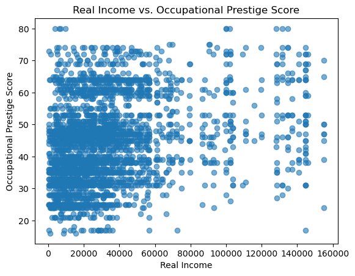

```python
import matplotlib.pyplot as plt
plt.scatter(df_gss_sample['realinc'], df_gss_sample['prestg10'], alpha=0.6)
plt.xlabel('Real Income')
plt.ylabel('Occupational Prestige Score')
plt.title('Real Income vs. Occupational Prestige Score')
plt.show()
```